**Neural Network**

|  | By Prof. Seungchul Lee iSystems Design Lab http://isystems.unist.ac.kr/ UNIST |
| --- | --- |

Table of Contents

# 0. Deep Learning Library

**Caffe**

[figure not shown]

- 장점
  - Image Processing에 많이 쓰임
  - 코드 작성없이 트레이닝 가능
  - Python 인터페이스
- 단점
  - GPU를 위해서는 C++/CUDA작성 필요
  - 큰 네트워크에 부적절

**Theano**

[figure not shown]

- 장점
  - Python + Numpy
  - Keras, Lasagna 등 추가 라이브러리 존재
- 단점
  - Theano 자체는 로우레벨 라이브러리
  - 에러메세지가 부정확함

**Tensorflow**

[figure not shown]

- 장점
  - Python + Numpy
  - Theano 보다 빠른 Compile time
  - Tensorboard 를 통한 visualization
  - 데이터와 모델의 병렬화
- 단점
  - 다른 library 들에 비해 느린속도
  - 계산 그래프가 Python으로 되어 있어서 느림

# 1. Deep learning vs. Machine learning

**Object recognition using machine learning**

[figure not shown]

**Neural Network**

|  | $\huge\rightarrow$ |  |
| --- | --- | --- |

# 2. Deep learning structure

- **"Deep"** neural networks 는 여러 개의 히든 레이어를 지닌 네트워크를 의미

[figure not shown]

**장점**

- 엔지니어가 좋은 feature를 선택해줄 필요 없이, 학습과정에서 feature가 학습됨

**단점**

- 모델의 학습을 위한 최적화가 어려움
- 엔지니어가 구조를 설계해주어야 함

# 3. Training Neural Networks

**Cost function**

- 우리의 모델이 예측하는 값과 실제 값이 얼마나 일치하는지 확인할 수 있는 function

$$ \min_{\theta} \sum_{i=1}^{m}\ell\left( h_{\theta}\left(x^{(i)}\right),y^{(i)}\right)$$

**Backpropagation**

- Cost function이 최소가 되도록 전체 파라미터가 가야할 방향 (Gradient) 를 찾음

[figure not shown]

**Gradient descent**

- 각각의 파라미터에 대해 Cost function이 최소가 되는 방향 (Gradient) 으로 파라미터를 업데이트

$$ \theta:= \theta - \alpha \nabla_{\theta} \left( h_{\theta} \left(x^{(i)}\right),y^{(i)}\right)$$

[figure not shown]

# 4. Neural Network in TensorFlow

[figure not shown]

```python
%%html
<center><iframe src="https://www.youtube.com/embed/z0bynQjEpII?start=2088&end=3137"
width="560" height="315" frameborder="0" allowfullscreen></iframe></center>
```

[video not shown]

- MNIST (Mixed National Institute of Standards and Technology database) 데이터셋 : 손글씨 데이터가 담겨있는 데이터셋
  - 각각의 손글씨는 $28 \times 28$ 의 이미지로 이루어져 있음
  - 분석과정에서는 이미지를 행렬로 생각하여 분석

[figure not shown]

## 4.1. Import Library

```python
# Import Library
import numpy as np
import matplotlib.pyplot as plt
import tensorflow as tf
```

## 4.2. Load MNIST example

- MNIST 예제 데이터 다운로드 링크
  - mnist.zip

```python
from six.moves import cPickle

mnist = cPickle.load(open('data_files/mnist.pkl', 'rb'))
trainimgs   = mnist.train.images
trainlabels = mnist.train.labels
testimgs    = mnist.test.images
testlabels  = mnist.test.labels
ntrain      = trainimgs.shape[0]
ntest       = testimgs.shape[0]
print ("Packages loaded")
```

```
Packages loaded
```

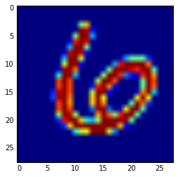

```python
plt.imshow(trainimgs[0, :].reshape(28, 28))
plt.show()
```

```python
print (trainlabels[0, :])
```

```
[ 0.  0.  0.  0.  0.  0.  1.  0.  0.  0.]
```

## 4.3. Define Network Component

- Network를 구성하는데 필요한 변수 (hidden layer 수, classes 개수 등) 정의

```python
n_input = 784
n_hidden = 100
n_classes = 10
```

## 4.4. Define Weights

- 학습될 변수 (파라미터) 정의

```python
weights = {
    'h1_w' : tf.Variable(tf.random_normal([n_input, n_hidden], stddev = 0.1)),
    'output_w' : tf.Variable(tf.random_normal([n_hidden, n_classes], stddev = 0.1)),
}
biases = {
    'h1_b' : tf.Variable(tf.random_normal([n_hidden], stddev = 0.1)),
    'output_b' : tf.Variable(tf.random_normal([n_classes], stddev = 0.1)),
}
```

## 4.5. Define Network Structure

- Network를 구성하는 구성요소와 TensorFlow code 설명
- 일반적으로 Network는 Linear combination, Nonlinear activation, Classification (Fully connected) 로 이루어져 있음

**1) Linear combination**

[figure not shown]

$$y_j = \left(\sum\limits_i \omega_{ij}x_i\right) + b_j$$$$\mathcal{y} = \mathcal{w}^T \mathcal{x} + \mathcal{b}$$

```
layer1 = tf.matmul(x, weights['h1_w']) + biases['h1_b']
```

**2) Nonlinear activation function**

[figure not shown]

```
layer1 = tf.nn.relu(layer1)
```

**3) Classification**

[figure not shown]

```
output_layer = tf.matmul(layer1, weights['output_w']) + biases['output_b']
```

[figure not shown]

```python
# Define Network
def net(x, weights, biases):
    # first hidden layer
    layer1 = tf.matmul(x, weights['h1_w']) + biases['h1_b']
    # non linear activate function
    layer1 = tf.nn.relu(layer1)

    # Output layer with linear activation
    output_layer = tf.matmul(layer1, weights['output_w']) + biases['output_b']
    return output_layer
```

## 4.6. Define Cost

- Neural Net의 output과 label $y$ 의 차이가 최소가 될 수 있도록 `cost`를 정의

```python
# Define Cost
learning_rate = 0.1
x = tf.placeholder(tf.float32, [None, n_input])
y = tf.placeholder(tf.float32, [None, n_classes])

nn_output = net(x, weights, biases)
cost = tf.reduce_mean(tf.square(nn_output - y))
optimizer = tf.train.GradientDescentOptimizer(learning_rate).minimize(cost)
```

- Tensor Graph
  - 엣지 (텐서) 와 노드로 이루어진 데이터 플로우 그래프 구조를 먼저 생성한 후 `tf.Session()`을 통해 수학적연산 진행

[figure not shown]

## 4.7. Define Variable

- 학습 과정에서 필요한 변수 (iteration 횟수 등) 정의

```python
batch_size = 50
n_iter = 2500
flag = 250
```

## 4.8. Optimize

```python
# Optimize
init = tf.initialize_all_variables()
sess = tf.Session()

sess.run(init)

# Training cycle
for epoch in range(n_iter):
    batch_x, batch_y = mnist.train.next_batch(batch_size)
    sess.run(optimizer, feed_dict={x: batch_x,  y: batch_y})
    c = sess.run(cost, feed_dict={x: batch_x,  y: batch_y})
    if epoch % flag == 0:
        print ("Iter : {}".format(epoch))
        print ("Cost : {}".format(c))
```

```
Iter : 0
Cost : 0.28099197149276733
Iter : 250
Cost : 0.060170598328113556
Iter : 500
Cost : 0.05656884238123894
Iter : 750
Cost : 0.0456811860203743
Iter : 1000
Cost : 0.048272453248500824
Iter : 1250
Cost : 0.03536101058125496
Iter : 1500
Cost : 0.03934542462229729
Iter : 1750
Cost : 0.03921915590763092
Iter : 2000
Cost : 0.037788357585668564
Iter : 2250
Cost : 0.03307906538248062
```

## 4.9. Test

```python
test_x, test_y = mnist.test.next_batch(1)
```

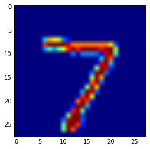

```python
plt.imshow(test_x.reshape(28, 28))
plt.show()
```

```python
predict_x = sess.run(nn_output, feed_dict={x: test_x})
print (np.argmax(predict_x, 1)[0])
```

```
7
```

```python
%%javascript
$.getScript('https://kmahelona.github.io/ipython_notebook_goodies/ipython_notebook_toc.js')
```